# General Information

Tabea Thies

2022-09-19

# Analysis of motor and cognitive scores

Load necessary packages

```r
library(tidyverse)
library(ggplot2)
library(lme4)
set.seed(42)
library(ordinalCont)
```

Load data set

```r
data <- read_delim('../data/demographics.csv')
```

## Disease duration

```r
data_dis_dur <-  filter(data, med_con %in% c('med-OFF'))

disdur_avgs <- data_dis_dur %>%
  summarise(M = round(mean(dis_dur, na.rm = T)),
            SD = round(sd(dis_dur, na.rm = T)))
disdur_avgs
```

```
## # A tibble: 1 x 2
##       M    SD
##   <dbl> <dbl>
## 1     8     5
```

## Age

```r
data_age <-  filter(data, med_con %in% c('CON', 'med-OFF'))

age_avgs <- data_age %>%
    group_by(med_con) %>%
    summarise(M = round(mean(age, na.rm = T)),
            SD = round(sd(age, na.rm = T)))
age_avgs
```

```
## # A tibble: 2 x 3
##   med_con     M    SD
##   <chr>   <dbl> <dbl>
## 1 CON        59     8
## 2 med-OFF    59     8
```

# UPDRS analysis

Disease effect: comparing motor scores between controls and PD in med-OFF reported under section 6.1

```r
data_CON_PD <-  filter(data, med_con %in% c('CON', 'med-OFF'))

UPDRS_avgs <- data_CON_PD %>%
  group_by(med_con) %>%
  summarise(M = round(mean(UPDRS_total, na.rm = T)),
            SD = round(sd(UPDRS_total, na.rm = T)),
            min = min(UPDRS_total, na.rm = T),
            max = max(UPDRS_total, na.rm = T))
UPDRS_avgs
```

```
## # A tibble: 2 x 5
##   med_con     M    SD   min   max
##   <chr>   <dbl> <dbl> <dbl> <dbl>
## 1 CON         4     4     0    13
## 2 med-OFF    25    11     9    48
```

```r
mdl1 <- lm(UPDRS_total ~ med_con  + age, data_CON_PD, REML = FALSE)
mdl1_null <- lm(UPDRS_total ~ 1 + age, data_CON_PD, REML = FALSE)

anova(mdl1, mdl1_null)
```

```
## Analysis of Variance Table
##
## Model 1: UPDRS_total ~ med_con + age
## Model 2: UPDRS_total ~ 1 + age
##   Res.Df    RSS Df Sum of Sq      F    Pr(>F)
## 1     22 1388.0
## 2     23 3944.6 -1   -2556.6 40.522 2.094e-06 ***
## ---
## Signif. codes:  0 '***' 0.001 '**' 0.01 '*' 0.05 '.' 0.1 ' ' 1
```

```r
axial_stats <- data_CON_PD %>%
  group_by(med_con) %>%
  summarise(M = round(mean(UPDRS_axial, na.rm = T)),
            SD = round(sd(UPDRS_axial, na.rm = T)))
axial_stats
```

```
## # A tibble: 2 x 3
##   med_con     M    SD
##   <chr>   <dbl> <dbl>
## 1 CON         0     0
## 2 med-OFF     4     3
```

```r
brady_stats <- data_CON_PD %>%
  group_by(med_con) %>%
  summarise(M = round(mean(UPDRS_brady, na.rm = T)),
            SD = round(sd(UPDRS_brady, na.rm = T)))
brady_stats
```

```
## # A tibble: 2 x 3
##   med_con     M    SD
##   <chr>   <dbl> <dbl>
## 1 CON         2     2
## 2 med-OFF    10     7
```

```r
rigid_stats <- data_CON_PD %>%
  group_by(med_con) %>%
  summarise(M = round(mean(UPDRS_rigidity, na.rm = T)),
            SD = round(sd(UPDRS_rigidity, na.rm = T)))
rigid_stats
```

```
## # A tibble: 2 x 3
##   med_con     M    SD
##   <chr>   <dbl> <dbl>
## 1 CON         2     2
## 2 med-OFF     7     3
```

```r
PIGD_stats <- data_CON_PD %>%
  group_by(med_con) %>%
  summarise(M = round(mean(UPDRS_PIGD, na.rm = T)),
            SD = round(sd(UPDRS_PIGD, na.rm = T)))
PIGD_stats
```

```
## # A tibble: 2 x 3
##   med_con     M    SD
##   <chr>   <dbl> <dbl>
## 1 CON         0     0
## 2 med-OFF     4     4
```

Levodopa effect: comparing motor scores between med-OFF and med-ON reported and plotted under section 7.1

```r
data_preop <-  filter(data, med_con %in% c('med-OFF', 'med-ON'))

UPDRS_avgs <- data_preop %>%
  group_by(med_con) %>%
  summarise(M = round(mean(UPDRS_total, na.rm = T)),
            SD = round(sd(UPDRS_total, na.rm = T)),
            min = min(UPDRS_total, na.rm = T),
            max = max(UPDRS_total, na.rm = T))
UPDRS_avgs
```

```
## # A tibble: 2 x 5
##   med_con     M    SD   min   max
##   <chr>   <dbl> <dbl> <dbl> <dbl>
## 1 med-OFF    25    11     9    48
## 2 med-ON     11     4     6    19
```

```r
mdl2 <- lm(UPDRS_total ~ med_con  + age, data_preop, REML = FALSE)
mdl2_null <- lm(UPDRS_total ~ 1 + age, data_preop, REML = FALSE)

anova(mdl2, mdl2_null)
```

```
## Analysis of Variance Table
##
## Model 1: UPDRS_total ~ med_con + age
## Model 2: UPDRS_total ~ 1 + age
##   Res.Df    RSS Df Sum of Sq      F    Pr(>F)
## 1     23 1608.0
## 2     24 2812.9 -1     -1205 17.235 0.0003859 ***
## ---
## Signif. codes:  0 '***' 0.001 '**' 0.01 '*' 0.05 '.' 0.1 ' ' 1
```

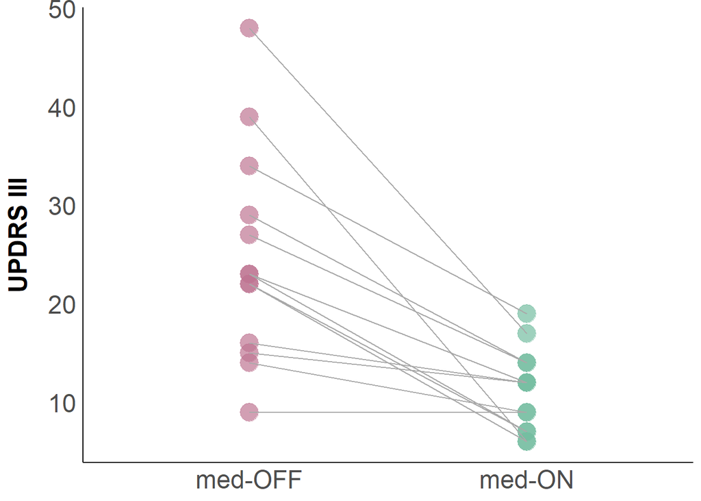

```r
UPDRS_avgs2 <- data_preop %>%
  group_by(med_con, speaker) %>%
  summarise(M = round(mean(UPDRS_total, na.rm = T)),
            SD = round(sd(UPDRS_total, na.rm = T)))

UPDRS_avgs2 %>%
  ggplot(aes(x = med_con, y = M, group = speaker)) +
  geom_point(aes(col = med_con), shape = 19, alpha = 0.7, size = 6) +
  geom_line(col = 'darkgrey') +
  theme_classic() +
  theme(legend.position = 'none')+
  scale_color_manual(values = c('#BE7592', '#74BDA0')) +
  xlab(NULL) +
  scale_x_discrete(labels = c('med-OFF','med-ON'))+
  ylab("UPDRS III")+
  theme(axis.title.y = element_text(face = 'bold', size = 18, margin = margin(r = 12)))+
  theme(strip.text.x = element_text(size=20, face="bold"),
        strip.background = element_blank())+
  theme(axis.text.x = element_text(size = 18),
        axis.text.y = element_text(size = 18)) +
  theme(axis.ticks.x = element_blank(),
        axis.ticks.y = element_blank())
```

DBS effect: comparing motor scores between DBS-OFF and DBS-ON reported and plotted under section 8.1

```r
data_postop <-  filter(data, med_con %in% c('med-OFF/DBS-OFF', 'med-OFF/DBS-ON'))

## remove data of PD03
data_postop <- data_postop[-c(5,6), ]

UPDRS_avgs <- data_postop %>%
  group_by(med_con) %>%
  summarise(M = round(mean(UPDRS_total, na.rm = T)),
            SD = round(sd(UPDRS_total, na.rm = T)),
            min = min(UPDRS_total, na.rm = T),
            max = max(UPDRS_total, na.rm = T))
UPDRS_avgs
```

```
## # A tibble: 2 x 5
##   med_con             M    SD   min   max
##   <chr>           <dbl> <dbl> <dbl> <dbl>
## 1 med-OFF/DBS-OFF    26     9    15    40
## 2 med-OFF/DBS-ON     13     9     3    34
```

```r
mdl3 <- lm(UPDRS_total ~ med_con  + age, data_postop, REML = FALSE)
mdl3_null <- lm(UPDRS_total ~ 1 + age, data_postop, REML = FALSE)

anova(mdl3, mdl3_null)
```

```
## Analysis of Variance Table
##
## Model 1: UPDRS_total ~ med_con + age
## Model 2: UPDRS_total ~ 1 + age
##   Res.Df    RSS Df Sum of Sq      F    Pr(>F)
## 1     21 1370.3
## 2     22 2371.4 -1     -1001 15.341 0.0007926 ***
## ---
## Signif. codes:  0 '***' 0.001 '**' 0.01 '*' 0.05 '.' 0.1 ' ' 1
```

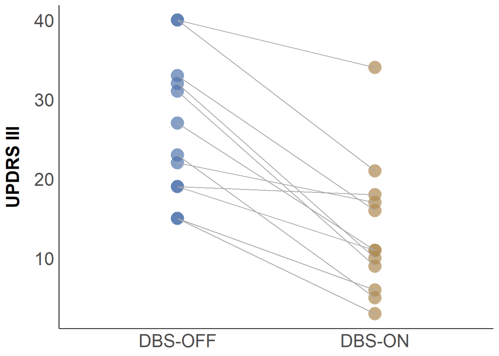

```r
UPDRS_avgs2 <- data_postop %>%
  group_by(med_con, speaker) %>%
  summarise(M = round(mean(UPDRS_total, na.rm = T)),
            SD = round(sd(UPDRS_total, na.rm = T)))

UPDRS_avgs2 %>%
  ggplot(aes(x = med_con, y = M, group = speaker)) +
  geom_point(aes(col = med_con), shape = 19, alpha = 0.7, size = 6) +
  geom_line(col = 'darkgrey') +
  theme_classic() +
  theme(legend.position = 'none')+
  scale_color_manual(values = c('#5275AD', '#AD8A52')) +
  xlab(NULL) +
  scale_x_discrete(labels = c('DBS-OFF','DBS-ON'))+
  ylab("UPDRS III")+
  theme(axis.title.y = element_text(face = 'bold', size = 18, margin = margin(r = 12)))+
  theme(strip.text.x = element_text(size=20, face="bold"),
        strip.background = element_blank())+
  theme(axis.text.x = element_text(size = 18),
        axis.text.y = element_text(size = 18)) +
  theme(axis.ticks.x = element_blank(),
        axis.ticks.y = element_blank())
```

Electrode/OFF effect: comparing motor scores between med-OFF and DBS-OFF reported and plotted under section 10.1

```r
data_OFF <-  filter(data, med_con %in% c('med-OFF', 'med-OFF/DBS-OFF'))

## remove data of PD03
data_OFF <- data_OFF[-c(5,6), ]

UPDRS_avgs <- data_OFF %>%
  group_by(med_con) %>%
  summarise(M = round(mean(UPDRS_total, na.rm = T)),
            SD = round(sd(UPDRS_total, na.rm = T)),
            min = min(UPDRS_total, na.rm = T),
            max = max(UPDRS_total, na.rm = T))
UPDRS_avgs
```

```
## # A tibble: 2 x 5
##   med_con             M    SD   min   max
##   <chr>           <dbl> <dbl> <dbl> <dbl>
## 1 med-OFF            26    11     9    48
## 2 med-OFF/DBS-OFF    26     9    15    40
```

```r
mdl4 <- lm(UPDRS_total ~ med_con  + age, data_OFF, REML = FALSE)
mdl4_null <- lm(UPDRS_total ~ 1 + age, data_OFF, REML = FALSE)

anova(mdl4, mdl4_null)
```

```
## Analysis of Variance Table
##
## Model 1: UPDRS_total ~ med_con + age
## Model 2: UPDRS_total ~ 1 + age
##   Res.Df    RSS Df Sum of Sq      F Pr(>F)
## 1     21 1996.3
## 2     22 1998.4 -1   -2.0735 0.0218  0.884
```

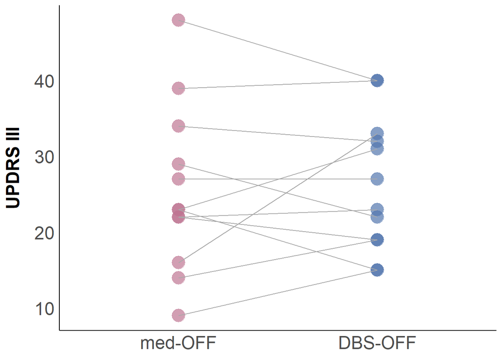

```r
UPDRS_avgs2 <- data_OFF %>%
  group_by(med_con, speaker) %>%
  summarise(M = round(mean(UPDRS_total, na.rm = T)),
            SD = round(sd(UPDRS_total, na.rm = T)))

UPDRS_avgs2 %>%
  ggplot(aes(x = med_con, y = M, group = speaker)) +
  geom_point(aes(col = med_con), shape = 19, alpha = 0.7, size = 6) +
  geom_line(col = 'darkgrey') +
  theme_classic() +
  theme(legend.position = 'none')+
  scale_color_manual(values = c('#BE7592', '#5275AD')) +
  xlab(NULL) +
  scale_x_discrete(labels = c('med-OFF','DBS-OFF'))+
  ylab("UPDRS III")+
  theme(axis.title.y = element_text(face = 'bold', size = 18, margin = margin(r = 12)))+
  theme(strip.text.x = element_text(size=20, face="bold"),
        strip.background = element_blank())+
  theme(axis.text.x = element_text(size = 18),
        axis.text.y = element_text(size = 18)) +
  theme(axis.ticks.x = element_blank(),
        axis.ticks.y = element_blank())
```

# Percentage changes in motor scores

Create subsets

```r
data_medOFF <-  filter(data, med_con %in% c('med-OFF'))
data_medON <-  filter(data, med_con %in% c('med-ON'))
data_DBSOFF <-  filter(data, med_con %in% c('med-OFF/DBS-OFF'))
data_DBSON <-  filter(data, med_con %in% c('med-OFF/DBS-ON'))
```

Calculate change in motoric subscores from med-OFF to med-ON reported under 7.1

```r
UPDRS_OFF_avgs <- data_medOFF %>%
  group_by(speaker) %>%
  summarise(UPDRS_medOFF = mean(UPDRS_total, na.rm = T),
            axial_medOFF = mean(UPDRS_axial, na.rm = T),
            rigid_medOFF = mean(UPDRS_rigidity, na.rm = T),
            brady_medOFF = mean(UPDRS_brady, na.rm = T),
            PIGD_medOFF = mean(UPDRS_PIGD, na.rm = T))

UPDRS_ON_avgs <- data_medON  %>%
  group_by(speaker) %>%
  summarise(UPDRS_medON = mean(UPDRS_total, na.rm = T),
            axial_medON = mean(UPDRS_axial, na.rm = T),
            rigid_medON = mean(UPDRS_rigidity, na.rm = T),
            brady_medON = mean(UPDRS_brady, na.rm = T),
            PIGD_medON = mean(UPDRS_PIGD, na.rm = T))

UPDRS_change <- inner_join(UPDRS_OFF_avgs, UPDRS_ON_avgs, by="speaker")

## calculate percentage change

UPDRS_change$total_change <- (UPDRS_change$UPDRS_medOFF - UPDRS_change$UPDRS_medON)/UPDRS_change$UPDRS_medOFF * 100
UPDRS_change$axial_change <- (UPDRS_change$axial_medOFF - UPDRS_change$axial_medON)/UPDRS_change$axial_medOFF * 100
UPDRS_change$rigid_change <- (UPDRS_change$rigid_medOFF - UPDRS_change$rigid_medON)/UPDRS_change$rigid_medOFF * 100
UPDRS_change$PIGD_change <- (UPDRS_change$PIGD_medOFF - UPDRS_change$PIGD_medON)/UPDRS_change$PIGD_medOFF * 100
UPDRS_change$brady_change <- (UPDRS_change$brady_medOFF - UPDRS_change$brady_medON)/UPDRS_change$brady_medOFF * 100


UPDRS_perc_change <- UPDRS_change %>%
  summarise(M = round(mean(total_change, na.rm = T)),
            SD = round(sd(total_change, na.rm = T)))
UPDRS_perc_change
```

```
## # A tibble: 1 x 2
##       M    SD
##   <dbl> <dbl>
## 1    49    24
```

```r
axial_perc_change <- UPDRS_change %>%
  summarise(M = round(mean(axial_change, na.rm = T)),
            SD = round(sd(axial_change, na.rm = T)))
axial_perc_change
```

```
## # A tibble: 1 x 2
##       M    SD
##   <dbl> <dbl>
## 1    49    44
```

```r
rigid_perc_change <- UPDRS_change %>%
  summarise(M = round(mean(rigid_change, na.rm = T)),
            SD = round(sd(rigid_change, na.rm = T)))
rigid_perc_change
```

```
## # A tibble: 1 x 2
##       M    SD
##   <dbl> <dbl>
## 1    52    18
```

```r
UPDRS_change$PIGD_change[UPDRS_change$PIGD_change == -Inf] <- NA

PIGD_perc_change <- UPDRS_change %>%
  summarise(M = round(mean(PIGD_change, na.rm = T)),
            SD = round(sd(PIGD_change, na.rm = T)))
PIGD_perc_change
```

```
## # A tibble: 1 x 2
##       M    SD
##   <dbl> <dbl>
## 1    53    56
```

```r
UPDRS_change$brady_change[UPDRS_change$brady_change == -Inf] <- NA

brady_perc_change <- UPDRS_change %>%
  summarise(M = round(mean(brady_change, na.rm = T)),
            SD = round(sd(brady_change, na.rm = T)))
brady_perc_change
```

```
## # A tibble: 1 x 2
##       M    SD
##   <dbl> <dbl>
## 1    54    30
```

Calculate change in motoric subscores from DBS-OFF to DBS-ON reported under 8.1

```r
UPDRS_OFF_avgs <- data_DBSOFF %>%
  group_by(speaker) %>%
  summarise(UPDRS_DBSOFF = mean(UPDRS_total, na.rm = T),
            axial_DBSOFF = mean(UPDRS_axial, na.rm = T),
            rigid_DBSOFF = mean(UPDRS_rigidity, na.rm = T),
            brady_DBSOFF = mean(UPDRS_brady, na.rm = T),
            PIGD_DBSOFF = mean(UPDRS_PIGD, na.rm = T))

UPDRS_ON_avgs <- data_DBSON  %>%
  group_by(speaker) %>%
  summarise(UPDRS_DBSON = mean(UPDRS_total, na.rm = T),
            axial_DBSON = mean(UPDRS_axial, na.rm = T),
            rigid_DBSON = mean(UPDRS_rigidity, na.rm = T),
            brady_DBSON = mean(UPDRS_brady, na.rm = T),
            PIGD_DBSON = mean(UPDRS_PIGD, na.rm = T))

UPDRS_change <- inner_join(UPDRS_OFF_avgs, UPDRS_ON_avgs, by="speaker")

## remove data of PD03
UPDRS_change <- UPDRS_change[-3, ]

## calculate percentage change

UPDRS_change$total_change <- (UPDRS_change$UPDRS_DBSOFF - UPDRS_change$UPDRS_DBSON)/UPDRS_change$UPDRS_DBSOFF * 100
UPDRS_change$axial_change <- (UPDRS_change$axial_DBSOFF - UPDRS_change$axial_DBSON)/UPDRS_change$axial_DBSOFF * 100
UPDRS_change$rigid_change <- (UPDRS_change$rigid_DBSOFF - UPDRS_change$rigid_DBSON)/UPDRS_change$rigid_DBSOFF * 100
UPDRS_change$PIGD_change <- (UPDRS_change$PIGD_DBSOFF - UPDRS_change$PIGD_DBSON)/UPDRS_change$PIGD_DBSOFF * 100
UPDRS_change$brady_change <- (UPDRS_change$brady_DBSOFF - UPDRS_change$brady_DBSON)/UPDRS_change$brady_DBSOFF * 100

UPDRS_perc_change <- UPDRS_change %>%
  summarise(M = round(mean(total_change, na.rm = T)),
            SD = round(sd(total_change, na.rm = T)))
UPDRS_perc_change
```

```
## # A tibble: 1 x 2
##       M    SD
##   <dbl> <dbl>
## 1    50    25
```

```r
axial_perc_change <- UPDRS_change %>%
  summarise(M = round(mean(axial_change, na.rm = T)),
            SD = round(sd(axial_change, na.rm = T)))
axial_perc_change
```

```
## # A tibble: 1 x 2
##       M    SD
##   <dbl> <dbl>
## 1    31    51
```

```r
rigid_perc_change <- UPDRS_change %>%
  summarise(M = round(mean(rigid_change, na.rm = T)),
            SD = round(sd(rigid_change, na.rm = T)))
rigid_perc_change
```

```
## # A tibble: 1 x 2
##       M    SD
##   <dbl> <dbl>
## 1    66    21
```

```r
PIGD_perc_change <- UPDRS_change %>%
  summarise(M = round(mean(PIGD_change, na.rm = T)),
            SD = round(sd(PIGD_change, na.rm = T)))
PIGD_perc_change
```

```
## # A tibble: 1 x 2
##       M    SD
##   <dbl> <dbl>
## 1     3    89
```

```r
brady_perc_change <- UPDRS_change %>%
  summarise(M = round(mean(brady_change, na.rm = T)),
            SD = round(sd(brady_change, na.rm = T)))
brady_perc_change
```

```
## # A tibble: 1 x 2
##       M    SD
##   <dbl> <dbl>
## 1    47    29
```

Calculate change in motoric subscores from med-OFF to DBS-ON reported under 9.1

```r
UPDRS_OFF_avgs <- data_medOFF %>%
  group_by(speaker) %>%
  summarise(UPDRS_medOFF = mean(UPDRS_total, na.rm = T),
            axial_medOFF = mean(UPDRS_axial, na.rm = T),
            rigid_medOFF = mean(UPDRS_rigidity, na.rm = T),
            brady_medOFF = mean(UPDRS_brady, na.rm = T),
            PIGD_medOFF = mean(UPDRS_PIGD, na.rm = T))

UPDRS_ON_avgs <- data_DBSON  %>%
  group_by(speaker) %>%
  summarise(UPDRS_DBSON = mean(UPDRS_total, na.rm = T),
            axial_DBSON = mean(UPDRS_axial, na.rm = T),
            rigid_DBSON = mean(UPDRS_rigidity, na.rm = T),
            brady_DBSON = mean(UPDRS_brady, na.rm = T),
            PIGD_DBSON = mean(UPDRS_PIGD, na.rm = T))

UPDRS_change <- inner_join(UPDRS_OFF_avgs, UPDRS_ON_avgs, by="speaker")

## calculate percentage change

UPDRS_change$total_change <- (UPDRS_change$UPDRS_medOFF - UPDRS_change$UPDRS_DBSON)/UPDRS_change$UPDRS_medOFF * 100
UPDRS_change$axial_change <- (UPDRS_change$axial_medOFF - UPDRS_change$axial_DBSON)/UPDRS_change$axial_medOFF * 100
UPDRS_change$rigid_change <- (UPDRS_change$rigid_medOFF - UPDRS_change$rigid_DBSON)/UPDRS_change$rigid_medOFF * 100
UPDRS_change$PIGD_change <- (UPDRS_change$PIGD_medOFF - UPDRS_change$PIGD_DBSON)/UPDRS_change$PIGD_medOFF * 100
UPDRS_change$brady_change <- (UPDRS_change$brady_medOFF - UPDRS_change$brady_DBSON)/UPDRS_change$brady_medOFF * 100

UPDRS_perc_change <- UPDRS_change %>%
  summarise(M = round(mean(total_change, na.rm = T)),
            SD = round(sd(total_change, na.rm = T)))
UPDRS_perc_change
```

```
## # A tibble: 1 x 2
##       M    SD
##   <dbl> <dbl>
## 1    38    39
```

```r
axial_perc_change <- UPDRS_change %>%
  summarise(M = round(mean(axial_change, na.rm = T)),
            SD = round(sd(axial_change, na.rm = T)))
axial_perc_change
```

```
## # A tibble: 1 x 2
##       M    SD
##   <dbl> <dbl>
## 1     8    85
```

```r
rigid_perc_change <- UPDRS_change %>%
  summarise(M = round(mean(rigid_change, na.rm = T)),
            SD = round(sd(rigid_change, na.rm = T)))
rigid_perc_change
```

```
## # A tibble: 1 x 2
##       M    SD
##   <dbl> <dbl>
## 1    56    52
```

```r
UPDRS_change$PIGD_change[UPDRS_change$PIGD_change == -Inf] <- NA

PIGD_perc_change <- UPDRS_change %>%
  summarise(M = round(mean(PIGD_change, na.rm = T)),
            SD = round(sd(PIGD_change, na.rm = T)))
PIGD_perc_change
```

```
## # A tibble: 1 x 2
##       M    SD
##   <dbl> <dbl>
## 1     1    87
```

```r
UPDRS_change$brady_change[UPDRS_change$brady_change == -Inf] <- NA

brady_perc_change <- UPDRS_change %>%
  summarise(M = round(mean(brady_change, na.rm = T)),
            SD = round(sd(brady_change, na.rm = T)))
brady_perc_change
```

```
## # A tibble: 1 x 2
##       M    SD
##   <dbl> <dbl>
## 1    15   101
```

# VAS analysis

Disease effect: comparing controls and PD in med-OFF reported under section 6.2.1

```r
VAS_avgs <- data_CON_PD %>%
  group_by(med_con) %>%
  summarise(M = round(mean(VAS, na.rm = T),1),
            SD = round(sd(VAS, na.rm = T),1))
VAS_avgs
```

```
## # A tibble: 2 x 3
##   med_con     M    SD
##   <chr>   <dbl> <dbl>
## 1 CON       7.3   1.6
## 2 med-OFF   7.4   1.9
```

```r
fit1 <- ocm(VAS ~ med_con + (1|speaker),
            data = data_CON_PD)
```

[output not shown]

```r
summary(fit1)
```

```
## Call:
## ocm(formula = VAS ~ med_con + (1 | speaker), data = data_CON_PD)
##
## Random effects:
##               Name Variance Std.Dev.
##  Intercept|speaker    0.888    0.942
##
## Coefficients:
##                Estimate   StdErr t.value p.value
## med_conmed-OFF -0.12903  0.74974 -0.1721  0.8665
```

Levodopa effect: comparing med-OFF and med-ON reported under section 7.2.1

```r
VAS_avgs <- data_preop  %>%
  group_by(med_con) %>%
  summarise(M = round(mean(VAS, na.rm = T),1),
            SD = round(sd(VAS, na.rm = T),1))
VAS_avgs
```

```
## # A tibble: 2 x 3
##   med_con     M    SD
##   <chr>   <dbl> <dbl>
## 1 med-OFF   7.4   1.9
## 2 med-ON    8.7   1.4
```

```r
fit2 <- ocm(VAS ~ med_con + (1|speaker),
            data = data_preop )
```

[output not shown]

```r
summary(fit2)
```

```
## Call:
## ocm(formula = VAS ~ med_con + (1 | speaker), data = data_preop)
##
## Random effects:
##               Name Variance Std.Dev.
##  Intercept|speaker    8.961    2.993
##
## Coefficients:
##               Estimate   StdErr t.value  p.value
## med_conmed-ON -2.64214  0.75477 -3.5006 0.002561 **
## ---
## Signif. codes:  0 '***' 0.001 '**' 0.01 '*' 0.05 '.' 0.1 ' ' 1
```

DBS effect: comparing DBS-OFF and DBS-ON reported under section 8.2.1

```r
VAS_avgs <- data_postop  %>%
  group_by(med_con) %>%
  summarise(M = round(mean(VAS, na.rm = T),1),
            SD = round(sd(VAS, na.rm = T),1))
VAS_avgs
```

```
## # A tibble: 2 x 3
##   med_con             M    SD
##   <chr>           <dbl> <dbl>
## 1 med-OFF/DBS-OFF   5.8   3
## 2 med-OFF/DBS-ON    7.4   2.2
```

```r
fit3 <- ocm(VAS ~ med_con + (1|speaker),
            data = data_postop )
```

[output not shown]

```r
summary(fit3)
```

```
## Call:
## ocm(formula = VAS ~ med_con + (1 | speaker), data = data_postop)
##
## Random effects:
##               Name Variance Std.Dev.
##  Intercept|speaker    8.362    2.892
##
## Coefficients:
##                       Estimate   StdErr t.value p.value
## med_conmed-OFF/DBS-ON -1.93964  0.72745 -2.6663 0.01791 *
## ---
## Signif. codes:  0 '***' 0.001 '**' 0.01 '*' 0.05 '.' 0.1 ' ' 1
```

Electrode effect: comparing med-OFF and DBS-OFF reported under section 10.2.1

```r
VAS_avgs <- data_OFF  %>%
  group_by(med_con) %>%
  summarise(M = round(mean(VAS, na.rm = T),1),
            SD = round(sd(VAS, na.rm = T),1))
VAS_avgs
```

```
## # A tibble: 2 x 3
##   med_con             M    SD
##   <chr>           <dbl> <dbl>
## 1 med-OFF           7.5     2
## 2 med-OFF/DBS-OFF   5.8     3
```

```r
fit4 <- ocm(VAS ~ med_con + (1|speaker),
            data = data_OFF)
```

[output not shown]

```r
summary(fit4)
```

```
## Call:
## ocm(formula = VAS ~ med_con + (1 | speaker), data = data_OFF)
##
## Random effects:
##               Name Variance Std.Dev.
##  Intercept|speaker    3.714    1.927
##
## Coefficients:
##                        Estimate StdErr t.value p.value
## med_conmed-OFF/DBS-OFF   1.4529 0.7086  2.0503 0.06095 .
## ---
## Signif. codes:  0 '***' 0.001 '**' 0.01 '*' 0.05 '.' 0.1 ' ' 1
```

DBS effect to Baseline: comparing med-OFF and DBS-ON reported under section .2.1

```r
data_ON_DBS <-  filter(data, med_con %in% c('med-OFF', 'med-OFF/DBS-ON'))

VAS_avgs <- data_ON_DBS  %>%
  group_by(med_con) %>%
  summarise(M = round(mean(VAS, na.rm = T),1),
            SD = round(sd(VAS, na.rm = T),1))
VAS_avgs
```

```
## # A tibble: 2 x 3
##   med_con            M    SD
##   <chr>          <dbl> <dbl>
## 1 med-OFF          7.4   1.9
## 2 med-OFF/DBS-ON   7.5   2.2
```

```r
fit5 <- ocm(VAS ~ med_con + (1|speaker),
            data = data_ON_DBS)
```

[output not shown]

```r
summary(fit5)
```

```
## Call:
## ocm(formula = VAS ~ med_con + (1 | speaker), data = data_ON_DBS)
##
## Random effects:
##               Name Variance Std.Dev.
##  Intercept|speaker    1.613     1.27
##
## Coefficients:
##                       Estimate  StdErr t.value p.value
## med_conmed-OFF/DBS-ON  -0.3183  0.6509  -0.489  0.6337
```

# Cognitive scores

averaged across group (PD vs CON) and visit (preop vs postop)

```r
data_cog <-  filter(data, med_con %in% c('CON', 'med-ON', 'med-OFF/DBS-ON'))

BDI_stats <- data_cog %>%
  group_by(med_con) %>%
  summarise(M = round(mean(BDI, na.rm = T)),
            SD = round(sd(BDI, na.rm = T)))
BDI_stats
```

```
## # A tibble: 3 x 3
##   med_con            M    SD
##   <chr>          <dbl> <dbl>
## 1 CON                2     3
## 2 med-OFF/DBS-ON     5     3
## 3 med-ON             6     4
```

```r
PANDA_stats <- data_cog %>%
  group_by(med_con) %>%
  summarise(M = round(mean(PANDA, na.rm = T)),
            SD = round(sd(PANDA, na.rm = T)))
PANDA_stats
```

```
## # A tibble: 3 x 3
##   med_con            M    SD
##   <chr>          <dbl> <dbl>
## 1 CON               24     5
## 2 med-OFF/DBS-ON    22     6
## 3 med-ON            22     5
```

```r
MMST_stats <- data_cog %>%
  group_by(med_con) %>%
  summarise(M = round(mean(MMST, na.rm = T)),
            SD = round(sd(MMST, na.rm = T)))
MMST_stats
```

```
## # A tibble: 3 x 3
##   med_con            M    SD
##   <chr>          <dbl> <dbl>
## 1 CON               29     1
## 2 med-OFF/DBS-ON    29     1
## 3 med-ON            28     2
```